# Mathematical methods of data processing. L-3

Yaroslav Kravchenko

10/16/2020

# Regression analysis

[figure not shown]

# Introduction

The marketingLib dataset contains the impact of three advertising medias (youtube, facebook and newspaper) on sales. Data are the advertising budget in thousands of dollars along with the sales (in thousands of units). The advertising experiment has been repeated 200 times. This is a simulated data. The aim of this paper is to perform regression analysis on the data from the given dataset.

# Data summary

```r
head(marketingLib)
```

```
##   youtube facebook newspaper sales
## 1  276.12    45.36     83.04 26.52
## 2   53.40    47.16     54.12 12.48
## 3   20.64    55.08     83.16 11.16
## 4  181.80    49.56     70.20 22.20
## 5  216.96    12.96     70.08 15.48
## 6   10.44    58.68     90.00  8.64
```

Note that *marketingLib* is a dataset from the **datarium** package, whereas *marketing* contains is a custom dataset which contains no outliers.

# Dependency assumption

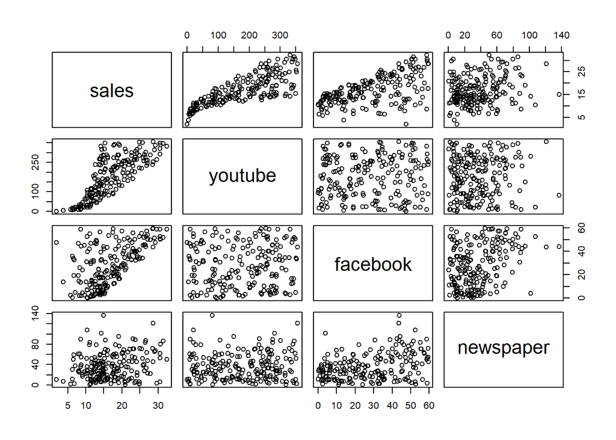

```r
pairs(~sales+youtube+facebook+newspaper, data=marketingLib)
```

Recall the classical regression model definition

$$\begin{aligned}\large
y=f(\vec{\beta}, x^{(1)},..,x^{(m)})+\varepsilon
\end{aligned}$$

where $f(•)$ is an unknown regression function, $y$ are the observations of the response-vector variable, $X=(x^{(1)},..,x^{(m)})$ - matrix of observations of the independent variables(regressors). denotes a random error of the regression. It is believed, the error variable is independent from from the regressor observations and has a zero mean.

There are three regressors in our case: youtube, facebook, newspaper. The dependent variable is **sales**. The scatterplot above gives an insight about the type of functional dependency between the variables. Visual analysis suggests a vivid relationship(linear?) between sales and youtube as well as between sales and facebook, though it seems to be less determined.

# Regression model parameters

```r
model<-lm(sales ~ youtube+facebook+newspaper,data = marketingLib)
summary(model)
```

```
##
## Call:
## lm(formula = sales ~ youtube + facebook + newspaper, data = marketingLib)
##
## Residuals:
##      Min       1Q   Median       3Q      Max
## -10.5932  -1.0690   0.2902   1.4272   3.3951
##
## Coefficients:
##              Estimate Std. Error t value Pr(>|t|)
## (Intercept)  3.526667   0.374290   9.422   <2e-16 ***
## youtube      0.045765   0.001395  32.809   <2e-16 ***
## facebook     0.188530   0.008611  21.893   <2e-16 ***
## newspaper   -0.001037   0.005871  -0.177     0.86
## ---
## Signif. codes:  0 '***' 0.001 '**' 0.01 '*' 0.05 '.' 0.1 ' ' 1
##
## Residual standard error: 2.023 on 196 degrees of freedom
## Multiple R-squared:  0.8972, Adjusted R-squared:  0.8956
## F-statistic: 570.3 on 3 and 196 DF,  p-value: < 2.2e-16
```

```r
confint(model)
```

```
##                   2.5 %     97.5 %
## (Intercept)  2.78851474 4.26481975
## youtube      0.04301371 0.04851558
## facebook     0.17154745 0.20551259
## newspaper   -0.01261595 0.01054097
```

Range and quartile data on residuals is used to determine, whether the residual random variable is normally distributed or not. As the data is simulated, the mean of the observations is 0, but the median differs from zero quite sufficiently. Coefficients sections contains information about the unknown parameters and provides critera statistics as well. The Intercept is $\vec{\beta_0}$. The Estimate column shows the beta estimator values, computed using the residual sum of squares method. Standard error is defined as standard deviation divided by the square root of the sample size. t-statistic is used to test the hypothesis of the form $H_0:\beta=\beta_0$ and the default value of $\beta_0$ is assumed to be 0. If the corresponding p=value is significant, the estimate of the corresponding unknown parameter is close to 0 and should not be included into the model. The residual standard error is the square root of the residual sum of squares divided by the residual degrees of freedom, that is 200-4=196. Given the RSE, confidence intervals can be calculated.

# Model correction

Due to insignificance of the “newspaper” regressor, it should be excluded from the model to make it fit the response better. The model’s paramters are in this way:

```r
model<-lm(sales ~ youtube+facebook,data = marketingLib)
summary(model)
```

```
##
## Call:
## lm(formula = sales ~ youtube + facebook, data = marketingLib)
##
## Residuals:
##      Min       1Q   Median       3Q      Max
## -10.5572  -1.0502   0.2906   1.4049   3.3994
##
## Coefficients:
##             Estimate Std. Error t value Pr(>|t|)
## (Intercept)  3.50532    0.35339   9.919   <2e-16 ***
## youtube      0.04575    0.00139  32.909   <2e-16 ***
## facebook     0.18799    0.00804  23.382   <2e-16 ***
## ---
## Signif. codes:  0 '***' 0.001 '**' 0.01 '*' 0.05 '.' 0.1 ' ' 1
##
## Residual standard error: 2.018 on 197 degrees of freedom
## Multiple R-squared:  0.8972, Adjusted R-squared:  0.8962
## F-statistic: 859.6 on 2 and 197 DF,  p-value: < 2.2e-16
```

```r
confint(model)
```

```
##                  2.5 %     97.5 %
## (Intercept) 2.80841159 4.20222820
## youtube     0.04301292 0.04849671
## facebook    0.17213877 0.20384969
```

The F-statistic has risen which means the regressors have more influence on the estimate and make it either more or less accurate, but it should first be proved.

## Fitted plane

Since the model includes two independent variables and one dependent, a 3D scatterplot could more or less precisely indicate the type of functional dependency between the variables.

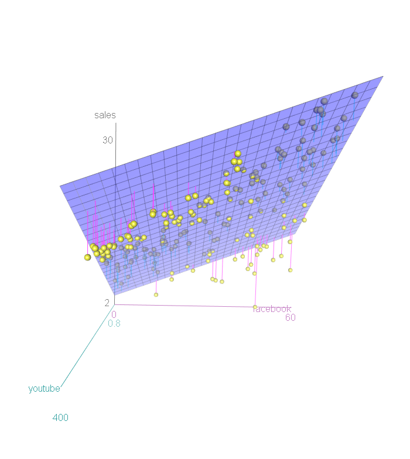

3D scatterplot

## Fitted lines

Having fixed one variable in a three-dimensional space, one can project the line onto two-dimensional basis.

### youtube given facebook

[interactive chart not shown]

### facebook given youtube

```r
model<-lm(sales ~ facebook+youtube,data = marketingLib)
ggPredict(model,se=TRUE,interactive=TRUE)
```

[interactive chart not shown]

Visual comparison of the two above plots helps outline an important point on the variables’ deviance: they both have high level of homoscedasticity, and combined with each other produce non-optimal fitted estimate of the response.

# Residuals assessment

The quality of the model is highly dependent on the residuals scale and distribution. For these reason, their assessment is crucial for further model evaluation.

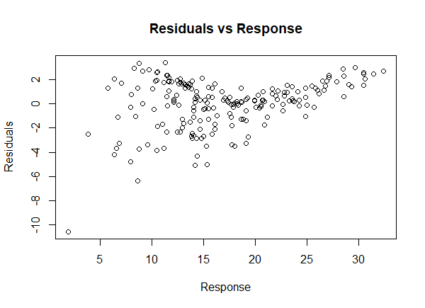

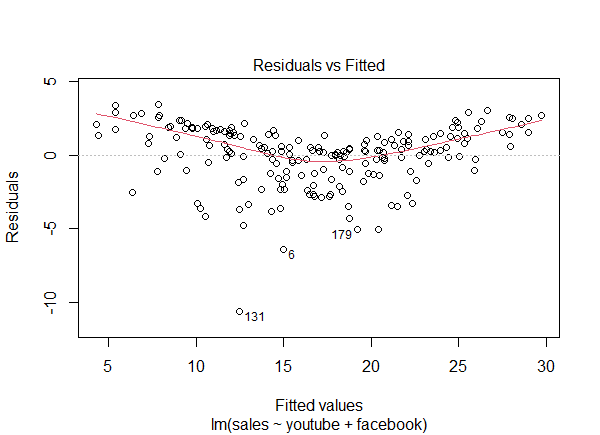

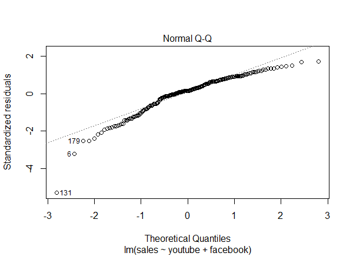

# Gauss-Markov assumptions

The Gauss–Markov theorem states that the ordinary least squares (OLS) estimator has the lowest sampling variance within the class of linear unbiased estimators, if the errors in the linear regression model are uncorrelated, have equal variances and expectation value of zero.

The Gauss–Markov assumptions concern the set of error random variables, ${\displaystyle \varepsilon _{i}}$:

• They have mean zero: ${\displaystyle \operatorname {E} [\varepsilon _{i}]=0.}$  
• They are homoscedastic, that is all have the same finite variance: ${\displaystyle \operatorname {Var} (\varepsilon _{i})=\sigma ^{2}<\infty }$ and  
• Distinct error terms are uncorrelated: ${\displaystyle {\text{Cov}}(\varepsilon _{i},\varepsilon _{j})=0,\forall i\neq j}$

The ordinary least squares estimator (OLS) is the function
$$\begin{aligned}\large
{\displaystyle {\widehat {\beta }}=(X'X)^{-1}X'y}
\end{aligned}$$

that minimizes the sum of squares of residuals

$$\begin{aligned}\large
{\displaystyle \sum _{i=1}^{n}\left(y_{i}-{\widehat {y}}_{i}\right)^{2}=\sum _{i=1}^{n}\left(y_{i}-\sum _{j=1}^{K}{\widehat {\beta }}_{j}X_{ij}\right)^{2}.}
\end{aligned}$$

The theorem states that the OLS estimator is the best linear estimator. The main idea of the proof is that the least-squares estimator is uncorrelated with every linear unbiased estimator of zero, i.e., with every linear combination ${\displaystyle a_{1}y_{1}+\cdots +a_{n}y_{n}}a_{1}y_{1}+\cdots +a_{n}y_{n}$ whose coefficients do not depend upon the unobservable ${}$ but whose expected value is always zero.

## Check the estimator

```r
model<-lm(sales ~ youtube+facebook,data = marketingLib)
gvlma(model)
```

```
##
## Call:
## lm(formula = sales ~ youtube + facebook, data = marketingLib)
##
## Coefficients:
## (Intercept)      youtube     facebook
##     3.50532      0.04575      0.18799
##
##
## ASSESSMENT OF THE LINEAR MODEL ASSUMPTIONS
## USING THE GLOBAL TEST ON 4 DEGREES-OF-FREEDOM:
## Level of Significance =  0.05
##
## Call:
##  gvlma(x = model)
##
##                       Value   p-value                   Decision
## Global Stat        194.6695 0.000e+00 Assumptions NOT satisfied!
## Skewness            58.3834 2.154e-14 Assumptions NOT satisfied!
## Kurtosis            90.2951 0.000e+00 Assumptions NOT satisfied!
## Link Function       45.8484 1.278e-11 Assumptions NOT satisfied!
## Heteroscedasticity   0.1426 7.057e-01    Assumptions acceptable.
```

### Link function

Link Function specifies the link between random and systematic components. It says how the expected value of the response relates to the linear predictor of explanatory variables; e.g., η = g(E(Yi)) = E(Yi). Low p-value implies low strength of the relationship.

### Global Stat

Global stat tests null hypothesis that the model is a linear combination of the predictors.

# Tuning

The model is by far not flowless, because the residuals observations contain outliers and the formula of the estimate function includes the *facebook* variable which adds additional noise and affects the RSS. For this reason, it should be excluded from the model.

```r
model2<-lm(sales ~ youtube,data = marketing)
```

## Residual outliers detection

There were a few heavy outliers in the initial dataset given the initial estimate function parameters.

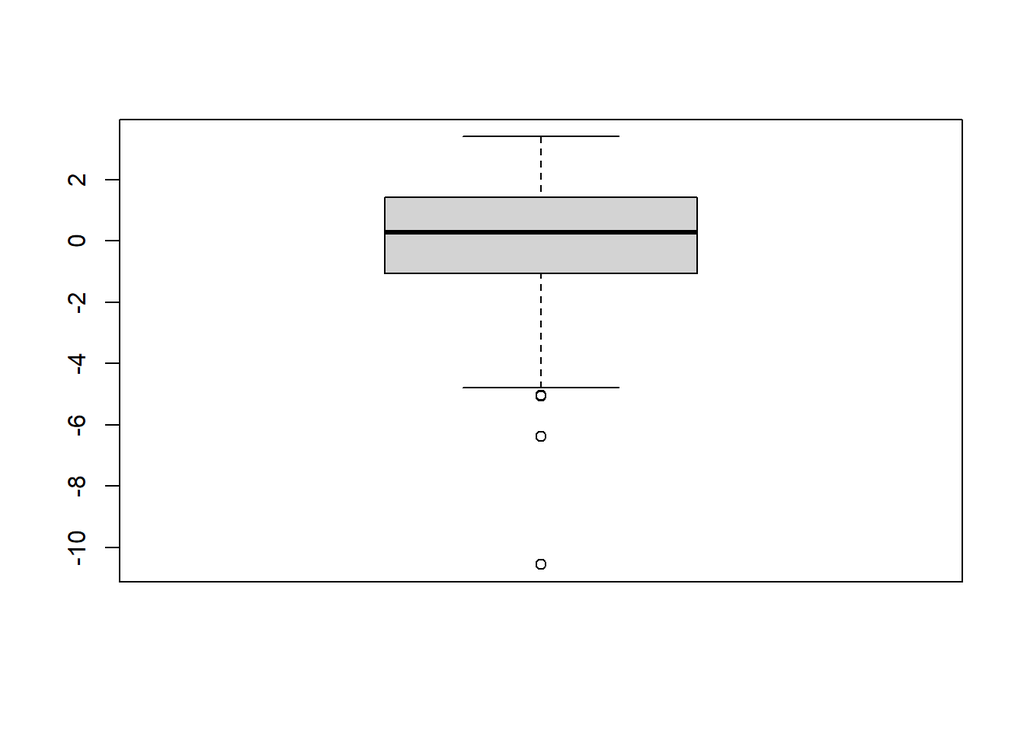

```r
model<-lm(sales ~ youtube+facebook,data = marketingLib)
boxplot(model$residuals)
```

A single regressor and a clean dataset promises a more precise model.

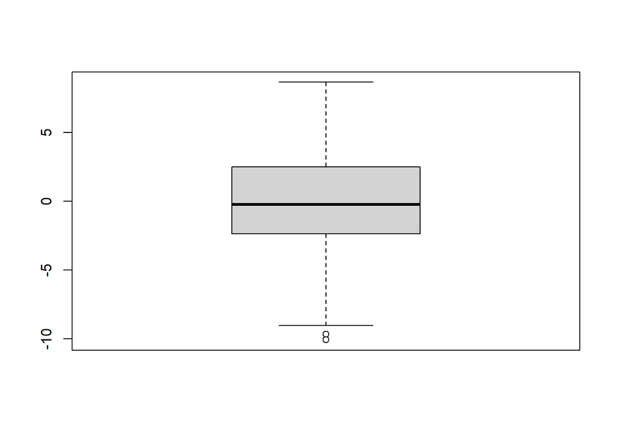

```r
boxplot(model2$residuals)
```

## Adjusted parameters

```r
summary(model2)
```

```
##
## Call:
## lm(formula = sales ~ youtube, data = marketing)
##
## Residuals:
##      Min       1Q   Median       3Q      Max
## -10.0632  -2.3454  -0.2295   2.4805   8.6548
##
## Coefficients:
##             Estimate Std. Error t value Pr(>|t|)
## (Intercept) 8.439112   0.549412   15.36   <2e-16 ***
## youtube     0.047537   0.002691   17.67   <2e-16 ***
## ---
## Signif. codes:  0 '***' 0.001 '**' 0.01 '*' 0.05 '.' 0.1 ' ' 1
##
## Residual standard error: 3.91 on 198 degrees of freedom
## Multiple R-squared:  0.6119, Adjusted R-squared:  0.6099
## F-statistic: 312.1 on 1 and 198 DF,  p-value: < 2.2e-16
```

```r
confint(model2)
```

```
##                  2.5 %     97.5 %
## (Intercept) 7.35566312 9.52256140
## youtube     0.04223072 0.05284256
```

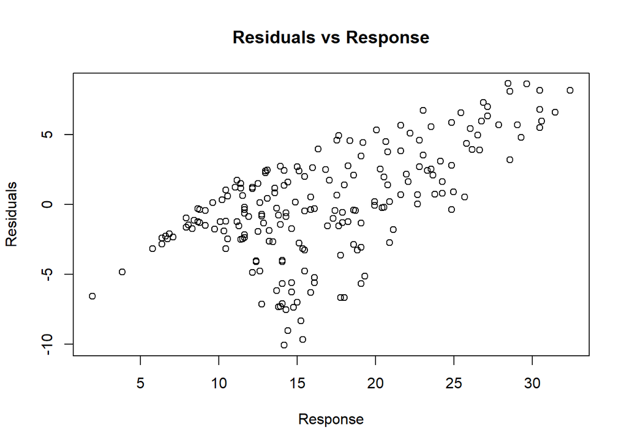

```r
plot(marketing$sales, model2$residuals, ylab = "Residuals", xlab = "Response", main = "Residuals vs Response")
```

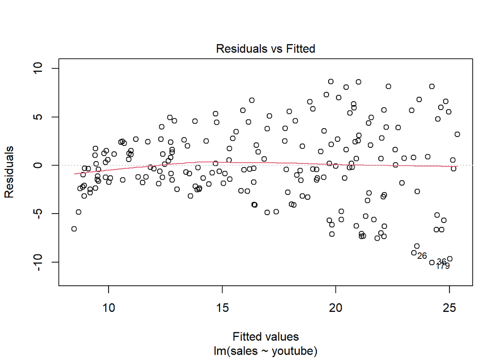

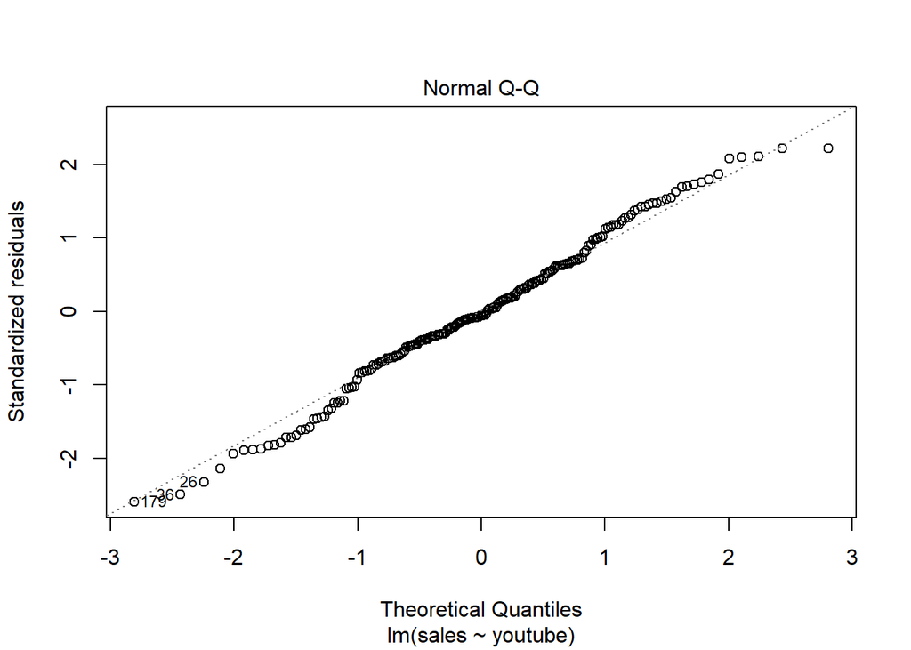

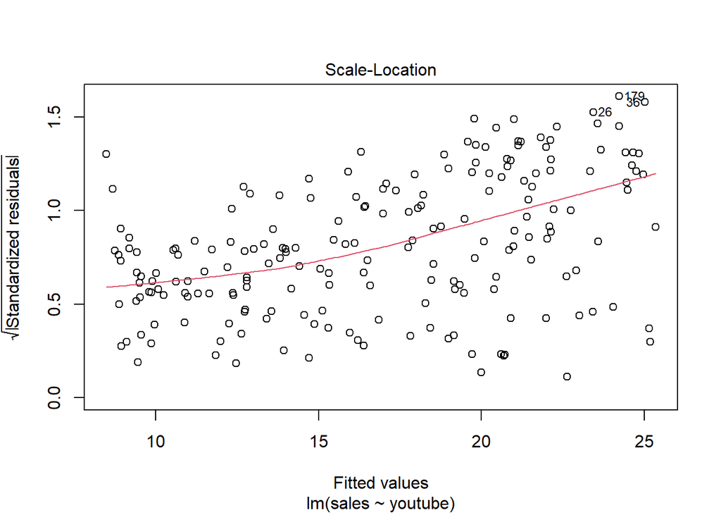

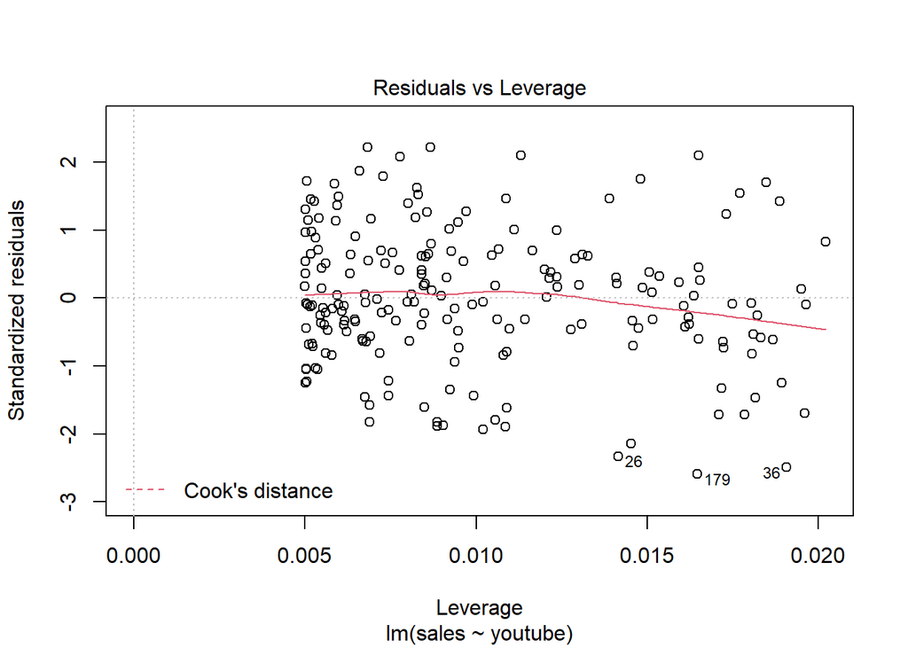

```r
plot(model2)
```

The normal Q-Q plot helps estimate “normality” of the residuals’ distribution. In this case, the tails are somewhat heavier than in the normal distribution. The “Cook’s distance” dashed curves don’t even appear on the Residuals vs Leverage plot. None of the points come close to having both high residual and leverage. Each point is therefore well approximated by the model.

## Evaluate model

```r
gvlma(model2)
```

```
##
## Call:
## lm(formula = sales ~ youtube, data = marketing)
##
## Coefficients:
## (Intercept)      youtube
##     8.43911      0.04754
##
##
## ASSESSMENT OF THE LINEAR MODEL ASSUMPTIONS
## USING THE GLOBAL TEST ON 4 DEGREES-OF-FREEDOM:
## Level of Significance =  0.05
##
## Call:
##  gvlma(x = model2)
##
##                     Value p-value                Decision
## Global Stat        5.3240 0.25564 Assumptions acceptable.
## Skewness           0.2619 0.60885 Assumptions acceptable.
## Kurtosis           0.4070 0.52352 Assumptions acceptable.
## Link Function      3.6906 0.05472 Assumptions acceptable.
## Heteroscedasticity 0.9646 0.32602 Assumptions acceptable.
```

It shall now be proved, that the model provides the best fit using the *trafo* package.

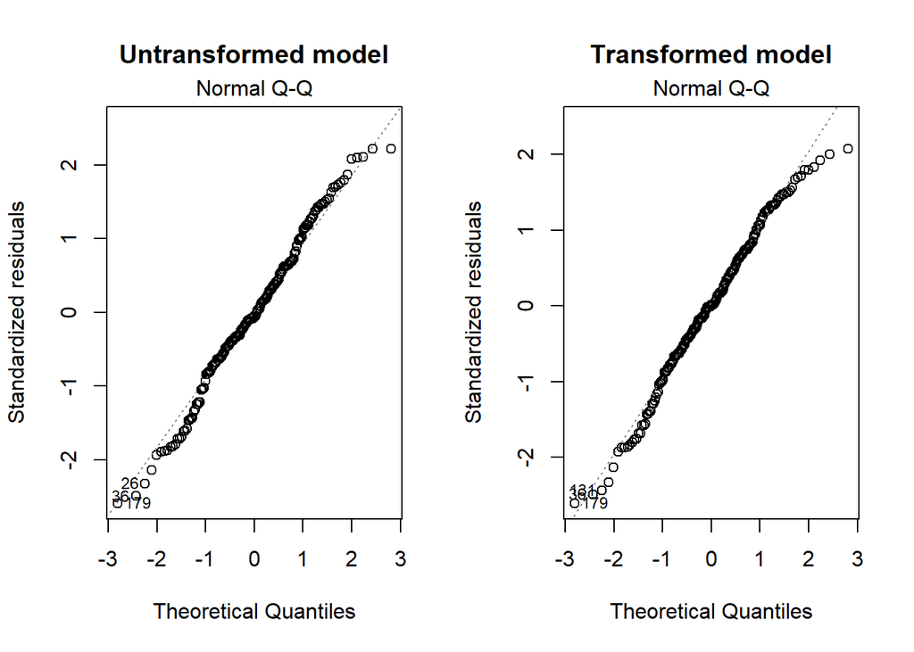

```
## Press [enter] to continue
```

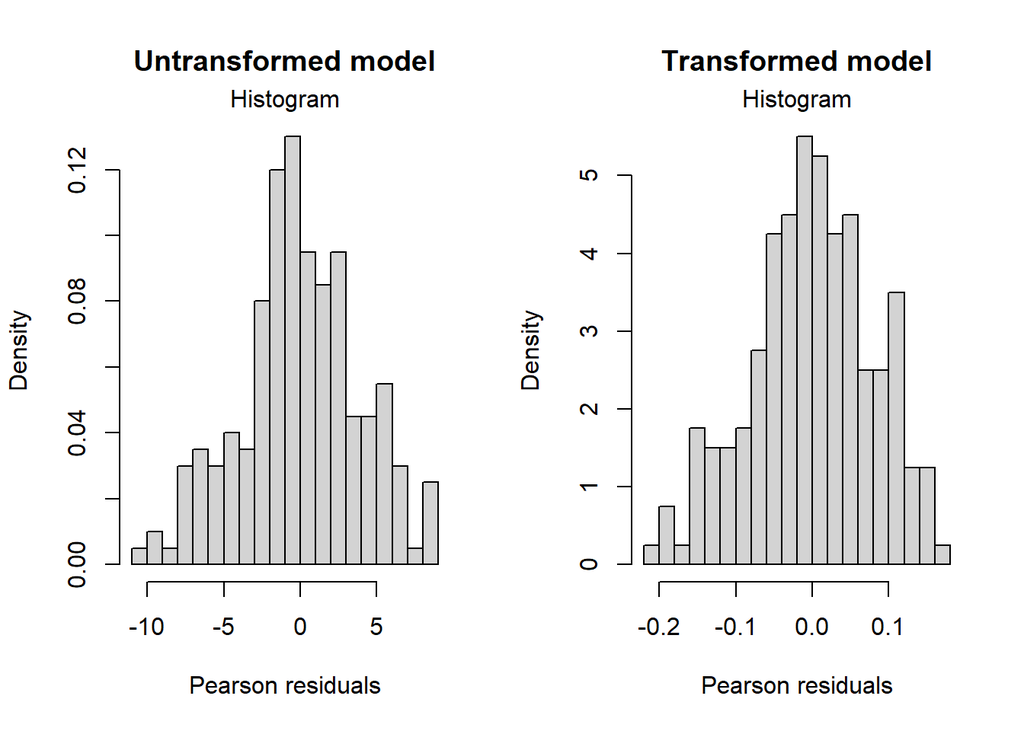

```
## Press [enter] to continue
```

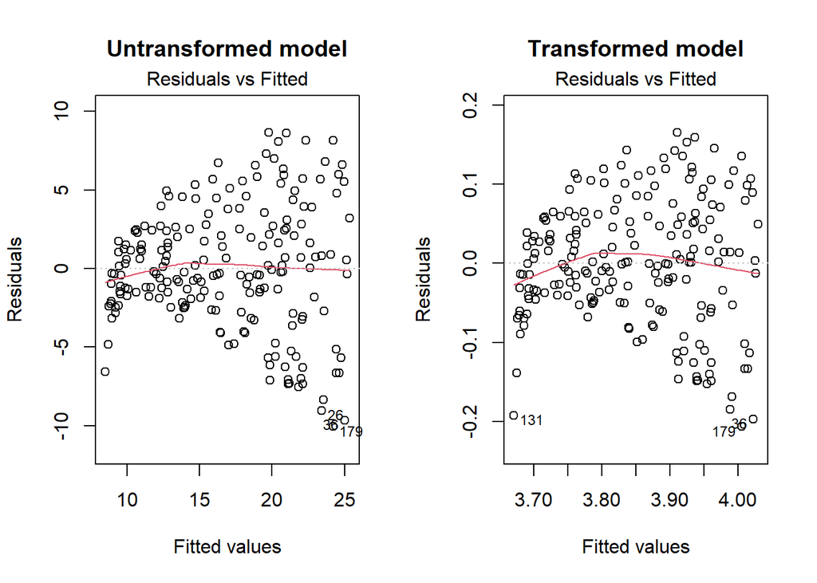

```
## Press [enter] to continue
```

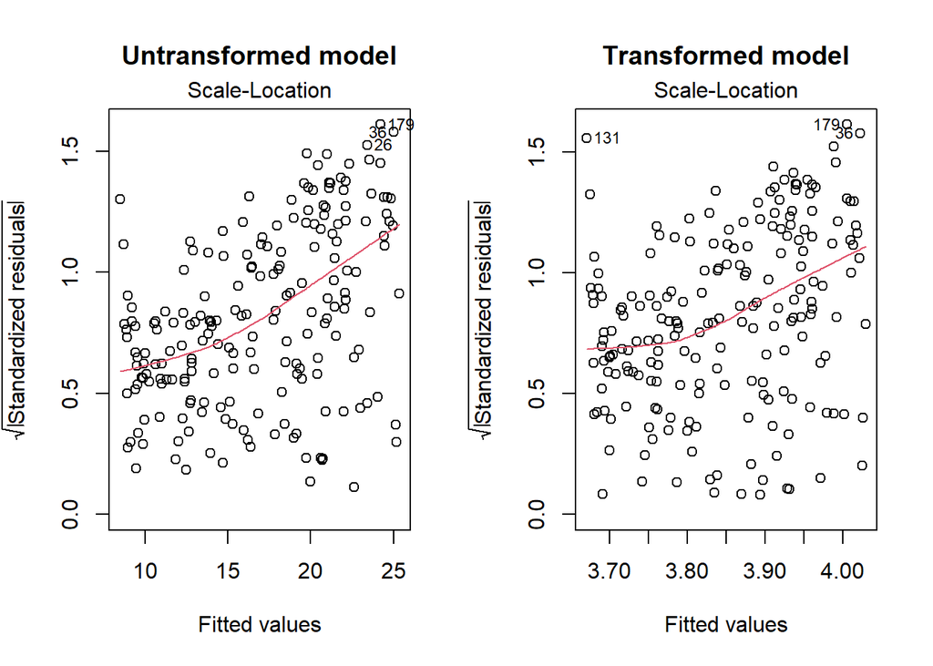

```
## Press [enter] to continue
```

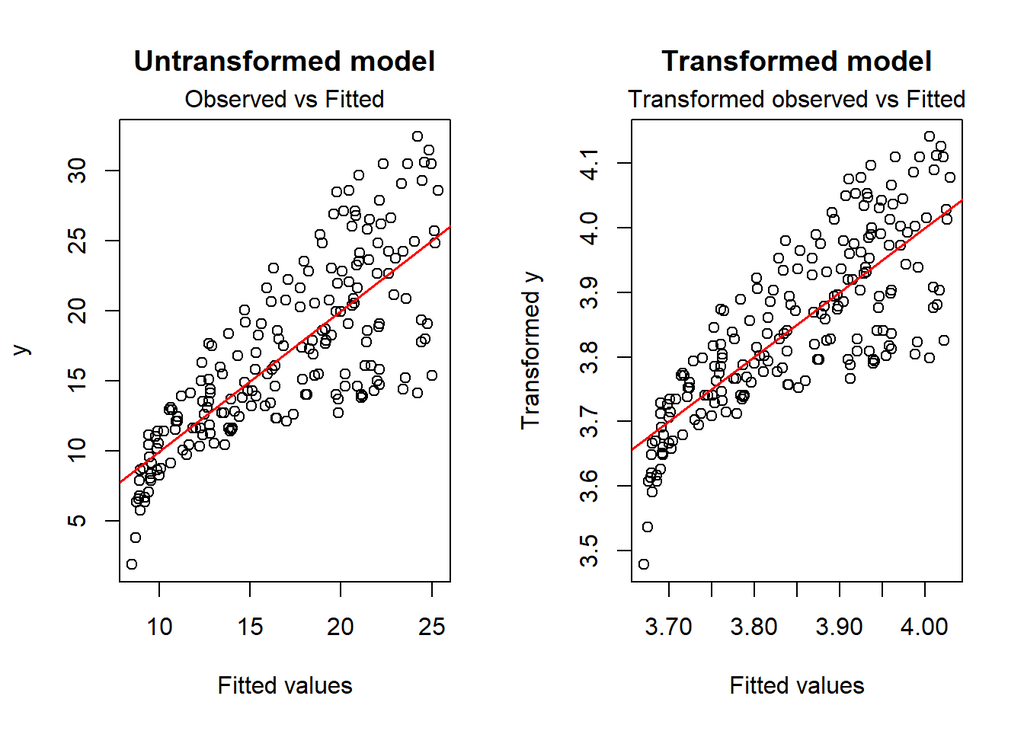

```
## Press [enter] to continue
```

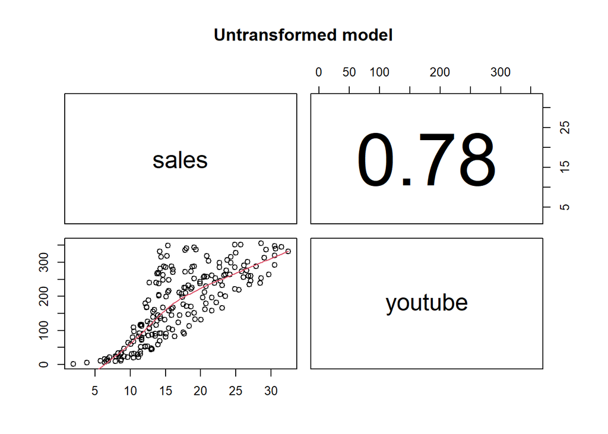

```
## Press [enter] to continue
```

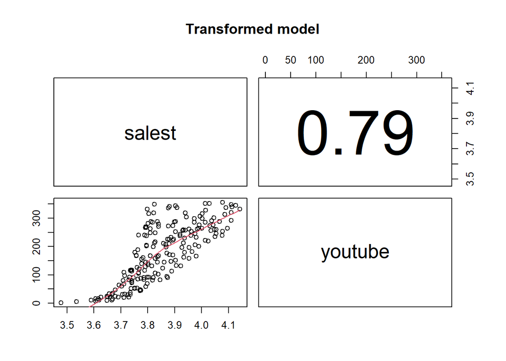

```
## Press [enter] to continue
```

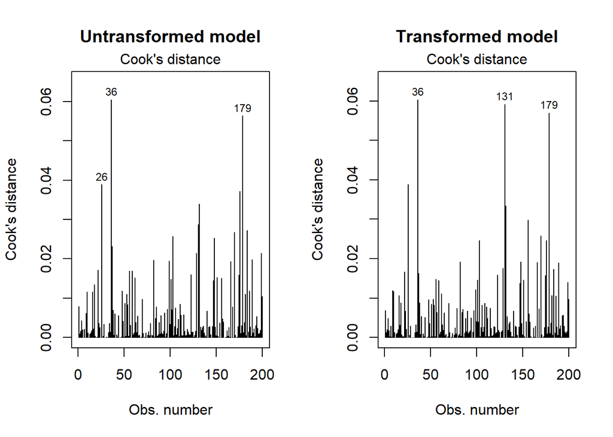

```
## Press [enter] to continue
```

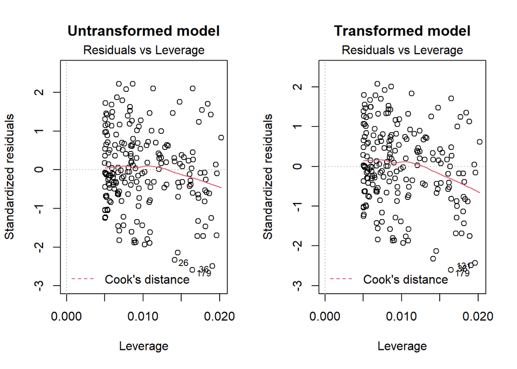

# Non-linear transformation

Exploratory analysis suggests, there is a semi-linear relationship between sales and youtube, but what if it is quadratic? The anova() function performs a hypothesis test comparing the two models - linear and quadratic:

```r
fit1<-lm(sales ~ youtube,data = marketing)
fit2<-lm(sales ~ youtube+I(youtube^2),data = marketing)
anova(fit1 ,fit2)
```

```
## Analysis of Variance Table
##
## Model 1: sales ~ youtube
## Model 2: sales ~ youtube + I(youtube^2)
##   Res.Df    RSS Df Sum of Sq      F  Pr(>F)
## 1    198 3027.6
## 2    197 2971.8  1    55.869 3.7036 0.05574 .
## ---
## Signif. codes:  0 '***' 0.001 '**' 0.01 '*' 0.05 '.' 0.1 ' ' 1
```

# Log-shift transformation

Transformations have the potential to correct certain violations of model assumptions and by doing so, allow an analysis to continue with the linear regression model. The point is, relationship between sales and youtube is in fact not linear, but rather logarithmic. Logging of the estimate however does not satisfy the Gauss-Markov theorem assumptions.

```r
gvlma(lm(log(sales) ~ youtube,data = marketing))
```

```
##
## Call:
## lm(formula = log(sales) ~ youtube, data = marketing)
##
## Coefficients:
## (Intercept)      youtube
##    2.189514     0.003156
##
##
## ASSESSMENT OF THE LINEAR MODEL ASSUMPTIONS
## USING THE GLOBAL TEST ON 4 DEGREES-OF-FREEDOM:
## Level of Significance =  0.05
##
## Call:
##  gvlma(x = lm(log(sales) ~ youtube, data = marketing))
##
##                      Value   p-value                   Decision
## Global Stat        360.662 0.000e+00 Assumptions NOT satisfied!
## Skewness            68.013 1.110e-16 Assumptions NOT satisfied!
## Kurtosis           261.289 0.000e+00 Assumptions NOT satisfied!
## Link Function       28.942 7.457e-08 Assumptions NOT satisfied!
## Heteroscedasticity   2.418 1.200e-01    Assumptions acceptable.
```

But what prevents the model to be just right in case of the given dataset? It turns out that the logarithm estimate function has to be adjusted by a certain parameter that would minimize divergence from the model, suggested by the trafo package.

```
## The default lambdarange for the Log shift opt transformation is calculated dependent on the data range. The lower value is set to -0.92 and the upper value to 30.48
```

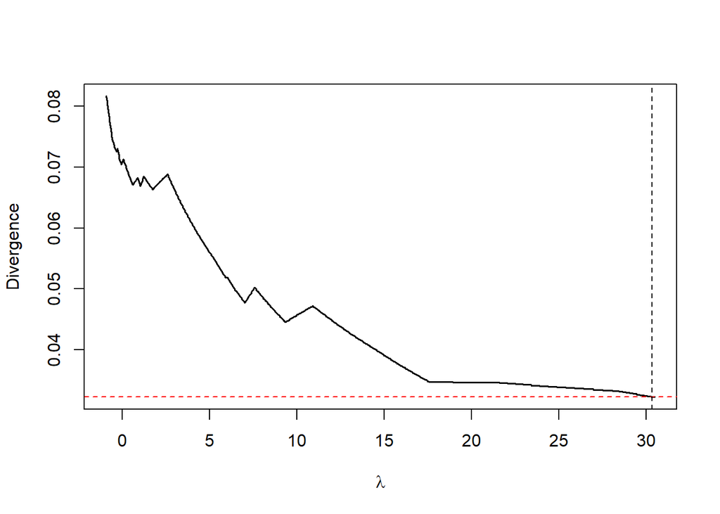

```r
model2<-lm(sales ~ youtube,data = marketing)
x<-logshiftopt(object = model2, method = "div.ks", plotit = TRUE)
```

```r
x$lambdavector[x$measvector == x$measoptim]
```

```
## [1] 30.30500 30.32227 30.33000 30.35500 30.38000 30.40500 30.43000 30.45500
## [9] 30.48000
```

```r
fit2<-lm(log(sales+23) ~ I(poly(youtube,6)),data = marketing)
gvlma(fit2)
```

```
##
## Call:
## lm(formula = log(sales + 23) ~ I(poly(youtube, 6)), data = marketing)
##
## Coefficients:
##          (Intercept)  I(poly(youtube, 6))1  I(poly(youtube, 6))2
##              3.67240               1.75224              -0.31139
## I(poly(youtube, 6))3  I(poly(youtube, 6))4  I(poly(youtube, 6))5
##              0.17041              -0.11074               0.20077
## I(poly(youtube, 6))6
##             -0.06667
##
##
## ASSESSMENT OF THE LINEAR MODEL ASSUMPTIONS
## USING THE GLOBAL TEST ON 4 DEGREES-OF-FREEDOM:
## Level of Significance =  0.05
##
## Call:
##  gvlma(x = fit2)
##
##                     Value p-value                Decision
## Global Stat        4.0554  0.3986 Assumptions acceptable.
## Skewness           0.2960  0.5864 Assumptions acceptable.
## Kurtosis           2.0060  0.1567 Assumptions acceptable.
## Link Function      0.9278  0.3354 Assumptions acceptable.
## Heteroscedasticity 0.8255  0.3636 Assumptions acceptable.
```

Interestingly, the more superior fit2 model satisfies the Gauss-Markov assumptions and is therefore preferable, though anova analysis implies the models perform only somewhat differently.

The following Response vs Residuals plot shall be compared with the initial one to assess the analysis and model adjustment results.

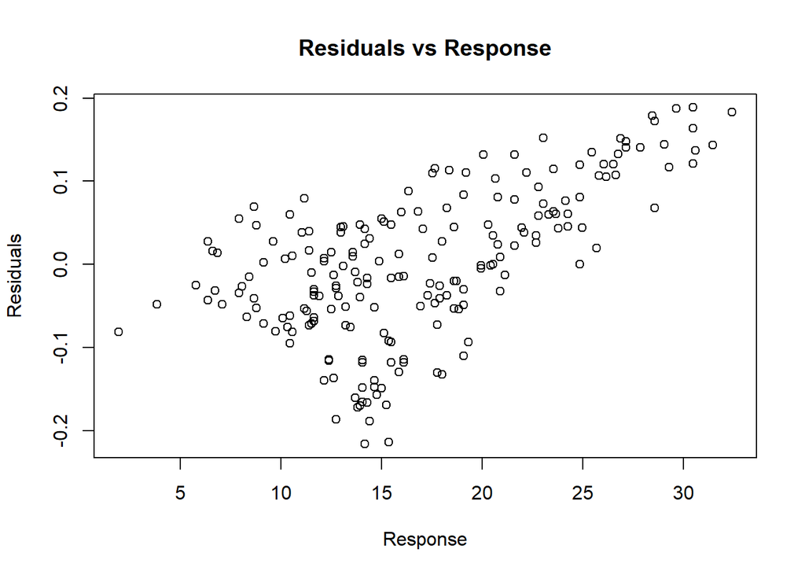

```r
plot(marketing$sales, fit2$residuals, main="Residuals vs Response", xlab = "Response", ylab = "Residuals")
```

```r
range(fit2$residuals)
```

```
## [1] -0.2158874  0.1885959
```

# Conclusion

The initial linear regression model contained too much noise caused by the *newspaper* variable. Relationship between *facebook* and sales was not clear and could not help optimise the model. However the *youtube* variable had a high correlation rate with the response and had to be more precisely analysed. Logarithmic dependence was obvious from the exploratory analysis phase, though linear relationship could be also possible. Adjustment of the logged response variable resulted into its best estimate, give that the regressor was non-linear(had a power of 6).